# BF_Final_Exam

## Fit ARIMA Model

- ARIMA (AutoRegressive Integrated Moving Average) is a powerful statistical model used for time series analyzing and forecasting.It combines three components:
- AutoRegressive (AR): Models the relationship between an observation and a number of lagged observations (past values).
- Integrated (I): Applies differencing to make the data stationary (removes trends or seasonality).
- Moving Average (MA): Captures the relationship between an observation and the residual errors from a moving average model applied to lagged observations.
- ARIMA is widely used for time series forecasting, particularly when the data exhibits patterns that are not easily captured by simpler models.

## Is the Time Series Data Stationary?

```r
adf_test <- adf.test(sales_ts_window)
print(adf_test)
```

```
##
##  Augmented Dickey-Fuller Test
##
## data:  sales_ts_window
## Dickey-Fuller = -5.4153, Lag order = 3, p-value = 0.01
## alternative hypothesis: stationary
```

##### Output Interpretation:

- Test for stationarity using the Augmented Dickey-Fuller (ADF) test.
- If the p-value is < 0.05, the data is stationary.
- Otherwise, the series needs differencing.

## How Many Differences Are Needed to Make it Stationary?

```r
ndiffs(sales_ts_window)  # Non-seasonal differencing
```

```
## [1] 0
```

```r
nsdiffs(sales_ts_window) # Seasonal differencing
```

```
## [1] 0
```

##### Output Interpretation:

- ndiffs gives the number of non-seasonal differences.
- nsdiffs indicates if seasonal differencing is needed.

## Is a Seasonality Component Needed?

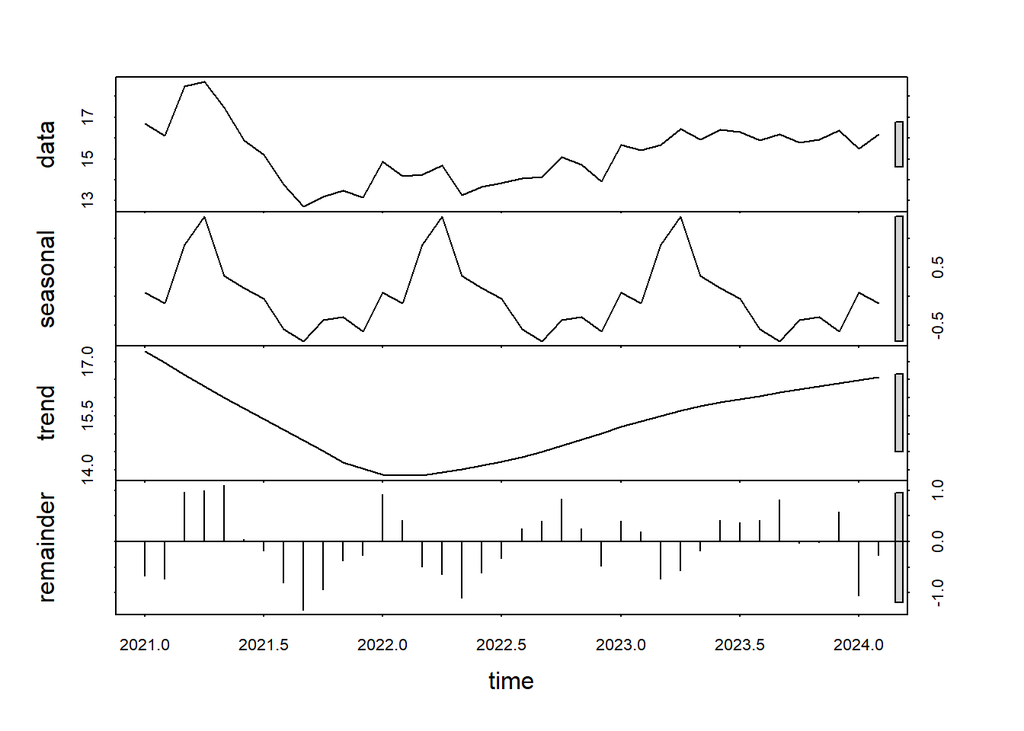

```r
stl_decomp <- stl(sales_ts_window, s.window = "periodic")
plot(stl_decomp)
```

##### Observation:

- Use nsdiffs or inspect the decomposition of the time series to confirm.
- If the seasonal component is significant, seasonality is required in the ARIMA model.